# Classification Project

Sal Calatola-Young, Christopher Ross, and Camille Zaug

6/11/2020

## Introduction

Directly from the Kaggle competition website,

> “Imagine standing at the check-out counter at the grocery store with a long line behind you and the cashier not-so-quietly announces that your card has been declined. In this moment, you probably aren’t thinking about the data science that determined your fate.” … “While perhaps cumbersome (and often embarrassing) in the moment, this fraud prevention system is actually saving consumers millions of dollars per year. Researchers from the IEEE Computational Intelligence Society (IEEE-CIS) want to improve this figure, while also improving the customer experience. With higher accuracy fraud detection, you can get on with your chips without the hassle.”

Fraud detection is actually something that one of our teammates is familiar with. Christopher had a brand new credit card stolen at the begining of the school year. Within several minutes of some suspicous purchases he received a phone call from Chase, and was asked to verify the activity. By flagging these suspicous purchases and a large cash advance Chase was able to prevent a long claims case to resolve the fraudlent purchases, and this is obviously beneficial to both the customer (Christopher) and the bank. So, the benefits of a statistical model like the one Vesta discusses is clearly beneficial. Some initial hypotheses when we began were that this problem would incredibly complex, and we would be surprised if the separation boundaries could be described linearly. So we assumed that QDA and KNN would be good places to start.

To set our problem up we first analyzed the data on Kaggle before downloading the dataset. Using the information on:

https://www.kaggle.com/c/ieee-fraud-detection/data,

we were able to interpret the individual data fields, but had some initial questions and concerns about how the data was orgainzed. After talking about the layout and how not all transactions have corresponding identity information, we decided to first do a merge on both sets. The next step would be to only retain predictors with less than 5% missing data. Finally, we remove missing data, and begin analyzing the data from here!

```r
library(vroom)
library(tidyverse)
library(ggplot2)
library(dplyr)
library(class)
library(klaR)
library(pls)
```

```r
set.seed(10)
```

```r
Train_ID  <- vroom("train_identity.csv")
Train_trans  <- vroom("train_transaction.csv")
```

## Look at the data

We see that there are lots of NAs and missing values

## Merge the data

```r
newdata <- merge(Train_trans,Train_ID,by="TransactionID", all.x=TRUE)

Train_ID = NULL
Train_trans = NULL
```

```r
newdata$P_emaildomain[is.na(newdata$P_emaildomain)] = "UNKNOWN"
newdata$R_emaildomain[is.na(newdata$R_emaildomain)] = "UNKNOWN"
newdata$DeviceInfo[is.na(newdata$DeviceInfo)] = "UNKNOWN"
newdata$DeviceType[is.na(newdata$DeviceType)] = "UNKNOWN"
```

Find the number of NAs

```r
sum(colSums(is.na(newdata)))
```

```
## [1] 114053764
```

```r
head(newdata)
```

[output not shown]

Insepect and retain variables with at least 95% of their data not NA

```r
n = nrow(newdata)

keeps = c()

for (colName in names(newdata)){
  # Remove any variable that is more than 5% NAs

  number_NA = sum(is.na(newdata[colName]))

  if (number_NA<n*.05){
    keeps = c(keeps,colName)
  }

}

print(keeps)
```

```
##   [1] "TransactionID"  "isFraud"        "TransactionDT"  "TransactionAmt"
##   [5] "ProductCD"      "card1"          "card2"          "card3"
##   [9] "card4"          "card5"          "card6"          "P_emaildomain"
##  [13] "R_emaildomain"  "C1"             "C2"             "C3"
##  [17] "C4"             "C5"             "C6"             "C7"
##  [21] "C8"             "C9"             "C10"            "C11"
##  [25] "C12"            "C13"            "C14"            "D1"
##  [29] "V95"            "V96"            "V97"            "V98"
##  [33] "V99"            "V100"           "V101"           "V102"
##  [37] "V103"           "V104"           "V105"           "V106"
##  [41] "V107"           "V108"           "V109"           "V110"
##  [45] "V111"           "V112"           "V113"           "V114"
##  [49] "V115"           "V116"           "V117"           "V118"
##  [53] "V119"           "V120"           "V121"           "V122"
##  [57] "V123"           "V124"           "V125"           "V126"
##  [61] "V127"           "V128"           "V129"           "V130"
##  [65] "V131"           "V132"           "V133"           "V134"
##  [69] "V135"           "V136"           "V137"           "V279"
##  [73] "V280"           "V281"           "V282"           "V283"
##  [77] "V284"           "V285"           "V286"           "V287"
##  [81] "V288"           "V289"           "V290"           "V291"
##  [85] "V292"           "V293"           "V294"           "V295"
##  [89] "V296"           "V297"           "V298"           "V299"
##  [93] "V300"           "V301"           "V302"           "V303"
##  [97] "V304"           "V305"           "V306"           "V307"
## [101] "V308"           "V309"           "V310"           "V311"
## [105] "V312"           "V313"           "V314"           "V315"
## [109] "V316"           "V317"           "V318"           "V319"
## [113] "V320"           "V321"           "DeviceType"     "DeviceInfo"
```

```r
bigdata <- na.omit(newdata[keeps])
newdata = NULL
dim(bigdata)
```

```
## [1] 578081    116
```

Partition a smaller subset for training and validation for non-KNN and KNN

```r
mmm = nrow(bigdata)

qdaSize = sample(mmm, round(0.5*mmm))

qdaCols = c("TransactionID","TransactionAmt", "ProductCD","card1","card2","card3","card5", "DeviceType")

qdadata = bigdata[qdaSize, c("isFraud", qdaCols)]

nnn = nrow(qdadata)

trainsamp = sample(nnn,round(.75*nnn))

fittrain_data <- qdadata[trainsamp,]
fittest_data <- qdadata[-trainsamp,]
```

```r
mmm = nrow(bigdata)

knnSize = sample(mmm, round(0.1*mmm))

knnCols = c("TransactionAmt", "ProductCD","card1","card2","card3","card5")

knndata = bigdata[knnSize, c("isFraud", knnCols)]

nnn = nrow(knndata)

trainsamp = sample(nnn,round(.75*nnn))

knn_train_data <- knndata[trainsamp, ]
knn_test_data <- knndata[-trainsamp,]
```

### Data Description

In this competition you are predicting the probability that an online transaction is fraudulent, as denoted by the binary target isFraud.

The data is broken into two files identity and transaction, which are joined by TransactionID. Not all transactions have corresponding identity information.

Categorical Features - Transaction

ProductCD card1 - card6 addr1, addr2 P_emaildomain R_emaildomain M1 - M9

Categorical Features - Identity

DeviceType DeviceInfo id_12 - id_38

Initially we organized the transactions to identity, but later realized that we needed to do the opposite.

## Building the Models and Training Errors

We decided to try using the categorical models that we learned in class:

- Logistic regression
- LDA
- QDA
- KNN

### Logistic Regression

We anticipate that this model will not perform very well since we expect the data classifications to have complex and potentially nonlinear separation.

```r
glm_fit <- glm(isFraud~TransactionAmt+ProductCD+card1+card2+card3+card5+DeviceType,
               data =fittrain_data, family=binomial)
```

```r
summary(glm_fit)
```

```
##
## Call:
## glm(formula = isFraud ~ TransactionAmt + ProductCD + card1 +
##     card2 + card3 + card5 + DeviceType, family = binomial, data = fittrain_data)
##
## Deviance Residuals:
##     Min       1Q   Median       3Q      Max
## -1.4783  -0.2422  -0.2002  -0.1855   2.9514
##
## Coefficients:
##                     Estimate Std. Error z value Pr(>|z|)
## (Intercept)       -5.271e+00  2.786e-01 -18.920  < 2e-16 ***
## TransactionAmt     7.723e-04  3.506e-05  22.024  < 2e-16 ***
## ProductCDH        -3.665e-01  6.646e-02  -5.513 3.52e-08 ***
## ProductCDR        -6.232e-01  6.826e-02  -9.130  < 2e-16 ***
## ProductCDS        -4.355e-02  8.299e-02  -0.525 0.599700
## ProductCDW        -3.650e-01  9.827e-02  -3.714 0.000204 ***
## card1             -2.329e-05  2.453e-06  -9.495  < 2e-16 ***
## card2             -4.813e-04  7.495e-05  -6.422 1.35e-10 ***
## card3              2.072e-02  1.461e-03  14.183  < 2e-16 ***
## card5             -1.194e-03  2.847e-04  -4.193 2.75e-05 ***
## DeviceTypemobile   3.127e-01  3.341e-02   9.358  < 2e-16 ***
## DeviceTypeUNKNOWN -8.753e-01  8.646e-02 -10.124  < 2e-16 ***
## ---
## Signif. codes:  0 '***' 0.001 '**' 0.01 '*' 0.05 '.' 0.1 ' ' 1
##
## (Dispersion parameter for binomial family taken to be 1)
##
##     Null deviance: 65377  on 216779  degrees of freedom
## Residual deviance: 59919  on 216768  degrees of freedom
## AIC: 59943
##
## Number of Fisher Scoring iterations: 6
```

Now we look at the probabibilites that our model predicts for the test data.

```r
glm_prob = predict(glm_fit,fittest_data,type = "response")

glm_pred = ifelse(glm_prob > 0.5, "0", "1")
```

```r
T = table(glm_pred,fittest_data$isFraud)
T
```

```
##
## glm_pred     0     1
##        0     2     0
##        1 69739  2519
```

```r
sens = T[2,2] / sum(T[,2])
spec = T[1,1] / sum(T[,1])

print(c(sens,spec))
```

```
## [1] 1.000000e+00 2.867754e-05
```

### LDA

We expect LDA to perform similarly to logistic regression.

```r
lda_fit <- lda(isFraud~TransactionAmt+ProductCD+card1+card2+card3+card5+DeviceType,
               data =fittrain_data)
```

Calculate LDA probabilities.

```r
lda_pred = predict(lda_fit, fittest_data, type="response")
```

As expected, LDA does pretty awful. Better than logistic regression since we’re doing a great job of predicting no fraud, but we’re not capturing the correct number of fraudulent cases.

```r
T = table(lda_pred$class,fittest_data$isFraud)
T
```

```
##
##         0     1
##   0 69638  2516
##   1   103     3
```

```r
sens = T[2,2] / sum(T[,2])
spec = T[1,1] / sum(T[,1])

print(c(sens,spec))
```

```
## [1] 0.001190949 0.998523107
```

### QDA

Now we reach a model that we think will have some success. It is unclear how nonlinear the boundaries of separation are, but we will be able to compare the error with KNN to see which performs better.

```r
qda_fit <- qda(isFraud~TransactionAmt+ProductCD+card1+card2+card3+card5+DeviceType, data=fittrain_data)
```

Calculate QDA probabilities.

```r
qda_pred = predict(qda_fit, fittest_data, type = "response")
```

```r
T = table(qda_pred$class,fittest_data$isFraud)
T
```

```
##
##         0     1
##   0 60583  1359
##   1  9158  1160
```

```r
sens = T[2,2] / sum(T[,2])
spec = T[1,1] / sum(T[,1])

print(c(sens,spec))
```

```
## [1] 0.4605002 0.8686856
```

### KNN

We expect KNN to be in the same ballpark as QDA, but since we choose to limit ourselves to relatively few predictors it is unclear which model will perform better.

```r
trainMatrixX = model.matrix(isFraud ~ ., knn_train_data)
trainY = knn_train_data$isFraud
testMatrixX = model.matrix(isFraud ~ ., knn_test_data)
testY = knn_test_data$isFraud
dim(trainMatrixX)
```

```
## [1] 43356    10
```

Check which model performs the best.

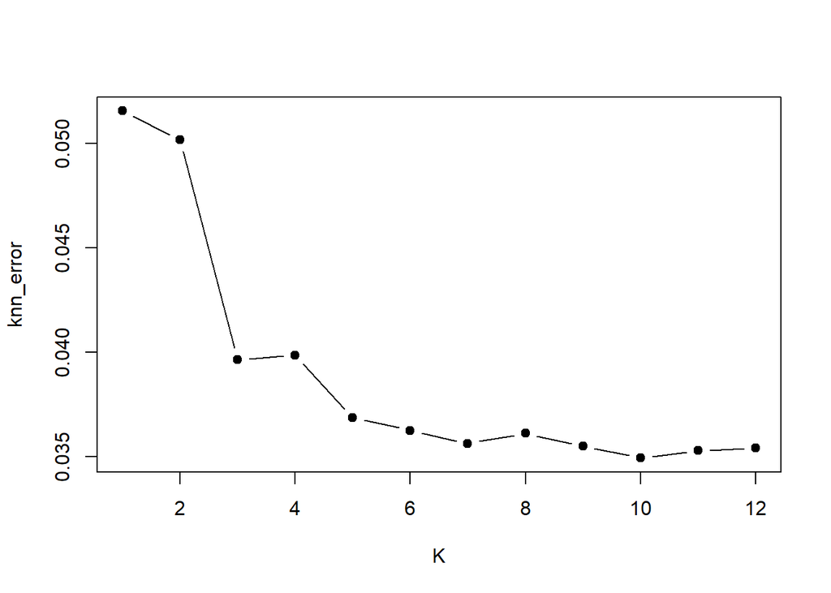

```r
K = 12

knn_error = rep(0,K)

for (i in 1:K){
  knn.pred=knn(trainMatrixX, testMatrixX, trainY, k=i)
  knn_error[i] = mean(knn.pred != testY)

}

plot(1:K, knn_error,type = "b",pch = 19,xlab = "K")
```

```r
Test_ID  <- vroom("test_identity.csv")
Test_trans  <- vroom("test_transaction.csv")

submit  <- vroom("sample_submission.csv")

submit$isFraud = 0
```

```r
newdata <- merge(Test_trans, Test_ID, by="TransactionID", all.x=TRUE)

Test_ID = NULL
Test_trans = NULL

nrow(newdata)
```

```
## [1] 506691
```

```r
qdatest = na.omit(newdata[, c("TransactionID", qdaCols)])
knntest = na.omit(newdata[, c("TransactionID", knnCols)])

newdata = NULL

nrow(qdatest)
```

```
## [1] 133960
```

```r
nrow(knntest)
```

```
## [1] 497023
```

```r
testMatrixX = model.matrix(~ .-TransactionID, knntest)
dim(testMatrixX)
```

```
## [1] 497023     10
```

```r
knn.pred=knn(trainMatrixX, testMatrixX, trainY, k=7)
```

```r
knnresults = data.frame(TransactionID = knntest$TransactionID)
knnresults$isFraud = knn.pred
knnresults
```

[output not shown]

```r
knnsubmit <- merge(submit[,1], knnresults, by="TransactionID", all.x=TRUE)
knnsubmit$isFraud[is.na(knnsubmit$isFraud)] = 1
```

```r
knnsubmit$TransactionID = as.integer(knnsubmit$TransactionID)
knnsubmit$isFraud = as.integer(knnsubmit$isFraud)
```

```r
qda_pred = predict(qda_fit, qdatest, type = "response")
```

```r
qdaresults = data.frame(TransactionID = qdatest$TransactionID)
qdaresults$isFraud = qda_pred$class
```

```r
qdasubmit <- merge(submit[,1], qdaresults, by="TransactionID", all.x=TRUE)
qdasubmit$isFraud[is.na(qdasubmit$isFraud)] = 1
```

```r
qdasubmit$TransactionID = as.integer(qdasubmit$TransactionID)
qdasubmit$isFraud = as.integer(qdasubmit$isFraud)
```

```r
write.csv(qdasubmit,"qda_Classification_Prediction.csv",row.names=FALSE)
```

```r
write.csv(knnsubmit,"knn_Classification_Prediction.csv",row.names=FALSE)
```

## Conclusion

Our initial hypotheses were fairly spot-on. Which is kind of surprising, but we think this just reenforces the material we covered in class. Since there is complex behavior dictating the behavior of fraudulent purchases it makes sense that the boundaries should also be complex and nonlinear.

Both QDA and KNN received similar Kaggle scores:

QDA: 0.497478

KNN: 0.498498

It’s unclear what kind of error the project is using. The leaderboard describes it as, “area under receiver operating characteristic curve” which is something that we are unfamiliar with. Compared to some of the top scores, it appears that both models do relatively abysmal.

## Reflections

Clearly there is a lot of information that our project does not take advantage of. Additionally, in order to compute the models in a reasonable amount of time we had to play around with different subset sizes. The non-KNN methods were able to converge to a solution much more quickly than KNN for a give size, so we ended up making the KNN sample significantly smaller. The company in charge of the competition made a post to expand on some of the variables a bit more, and had we more time and paitence, then we would look into ways that we could incorporate the other predictors into a more sophisticated model along with more advanced methods.